# Deconvolving with SiNMFiD

## View results in 3D

We’re going to need a list of the clusters used in the analysis to determine exactly which to inspect. `summarize_clusters` returns a frequency table from which we can extract names.

```r
summarize_clusters(filepath,
                   analysis_name)
```

```
#> MOp cluster frequency
#> clusts
#>            Astro             Car3             Endo              IOL
#>            17854              896             1863             1127
#>          L2/3 IT          L4/5 IT            L5 ET            L5 IT
#>            53119            95965             3177            23359
#>            L5 NP            L5 PT            L6 CT            L6 IT
#>            14058             2663            63128            32469
#>              L6b            Lamp5            Macro            Micro
#>             5198            11672              358             8560
#>            Oligo              OPC            Pvalb Pvalb_Chandelier
#>            22679             5475            11689              182
#>         SMC-Peri             Sncg              Sst        Sst_Chodl
#>             1050             4248            14196              752
#>              Vip             VLMC             VPIA
#>            15050             1596              821
```

With a cell type of interest, here `L2/3 IT` excitatory neurons, we can directly view cell type loading in space with `view_in_rgl`, which opens an interactive window with our data.

```r
view_in_rgl(filepath,
    analysis_name,
    spatial_data_name,
    rand.seed = rand_seed,
    "L2/3 IT")
```

```
#> Created directory at sinmfid/MOp/ISH_ccf_subset_927/123/downstream_output/plots
#> Created directory at sinmfid/MOp/ISH_ccf_subset_927/123/downstream_output/plots/gifs
```

We can generate gifs summarizing the distribution over the 3D volume with the `generate_loading_gifs` function. Here, I’m providing it with a list of excitatory neuron types to plot. They save in the `downstream_output/plots` directory of the analysis run-specific folder.

```r
generate_loading_gifs(filepath,
                      analysis_name,
                      spatial_data_name,
                      rand.seed = rand_seed,
                      cell.types.plot = c("L2/3 IT", "L4/5 IT", "L5 ET",
                                          "L5 IT", "L5 NP", "L5 PT",
                                          "L6 CT","L6 IT","L6b"))
```

## Derived data

The data generated over the analysis can be more directly quantified through several methods. The `analyze_gene_signatures` function calculates the cosine similarity between gene signatures, yielding a matrix of similarities between cell types. Its `plot` utility returns a heatmap of correlations and a dendrogram of cell type relationships – this robustly recapitulates known cell type hierarchies and can be used for refining call type annotations.

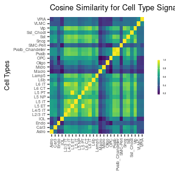

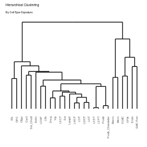

```r
analyze_gene_signatures(filepath,
                      analysis_name,
                      spatial_data_name)

plot_analyze_gene_signatures(filepath,
                      analysis_name,
                      spatial_data_name)
```

`analyze_spatial_correlation` and its `plot` utility provide similar functionality, instead calculating the Pearson correlation between derived cell type distributions. This can be interpreted as a metric of cell type co-occurrence.

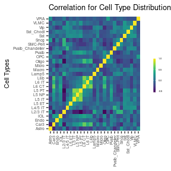

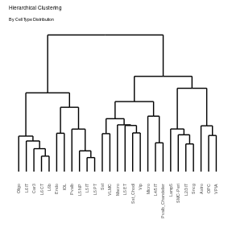

```r
analyze_spatial_correlation(filepath,
                      analysis_name,
                      spatial_data_name)

plot_analyze_spatial_correlation(filepath,
                      analysis_name,
                      spatial_data_name)
```

`calculate_wasserstein` finds the Wasserstein distance (sometimes call the Earth Mover’s distance) between cell type distributions. Think of this as the energy required to shift one distribution to the location of the other. This better quantifies distance between layers or regions specific to a cell type.

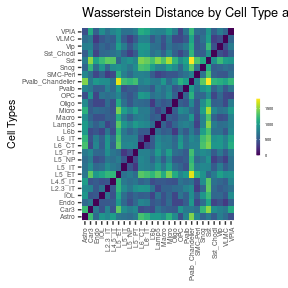

```r
calculate_wasserstein(filepath,
                      analysis_name,
                      spatial_data_name)

plot_calculate_wasserstein(filepath,
                      analysis_name,
                      spatial_data_name)
```

This does not account for all of the functionality of the `SiNMFiD` package! Additional vignettes should be expected with more information on how to manipulate plotting, preprocess spatial data, and optimize analyses more generally.